# **Influencia de los servicios de Streaming**

```r
library(readr)
library(dplyr)
library(DescTools)
library(car)
library(raster)
```

```r
library(ggplot2)
library(ggthemes)
library(hexbin)
library(modeest)
library(plotrix)
library(gmodels)
```

# **P2 Segunda entrega**

[figure not shown]

## *1. Introducción*

Las plataformas de streaming tuvieron un gran impacto en el tiempo de pandemia, debido a que estas plataformas se convirtieron en una opción de entretenimiento accesible que se encontraba desde la comodidad de su hogar.

*Datos previos*

Un estudio realizado por *Global Entertainment & Media Outlook (2019-2023)*, elaborado por la firma PwC. Afirma que para el año 2023 se evidenciaría un incremento del 19% solo en Perú de las plataformas de streaming. Otra encuesta realizada por Directv indica que usuarios en Perú miraron en promedio 23 horas de contenido y prefirieron hacerlo a través de un Smart TV. Además Sherlock Communications, según el estudio que realizó en el año 2021, indicó que el 68% de los peruanos tiene como plataforma favorita de streaming a Netflix.

### *1.1. Relevancia*

El entretenimiento cumple un rol fundamental en la vida de una persona, ya que ayuda a la salud mental como un modo de recreación, además permite que los usuarios puedan interactuar con sus amigos, familiares o colegas; sin estar presentes. Es por ello que logramos realizar una encuesta donde el usuario podrá darnos su opinión con respecto a estas plataformas, logrando así saber la influencia que tienen estos servicios con el usuario, además también se verificará si generan un aporte productivo o infructuoso con la vida diaria. Asimismo, estas plataformas obsequian al usuario beneficios con el primer pago del mes gratis, esto sucede al momento de inscribirse por primera vez, adicional un contenido variado.

#### *Objetivos del estudio*

*Objetivo principal:*

Saber cuál es el nivel del consumo que tienen los servicios de streaming en Perú y cuál es el aporte que brindan al usuario con respecto al área de entretenimiento que forma parte fundamental en el desarrollo humano y calidad de vida. Además, nos permitirá estimar si el usuario hace un uso moderado de las plataformas de streaming o le está generando alguna dependencia que puede llegar a repercutir en su bienestar.

*Objetivo secundarios:*

- Identificar cuál es la plataforma con mayor demanda en los usuarios del territorio peruano.
- Estudiar el dispositivo de preferencia para el uso de plataformas de Streaming de los usuarios.
- Conocer cuál es el presupuesto que invierten los usuarios en los servicios de Streaming.
- Conocer cuál es el género de entretenimiento con mayor grado de preferencia de los usuarios que utilizan plataforma de streaming.
- Identificar cuál ha sido la desventaja que consideran los usuarios al usar las plataformas de streaming.

### *1.2. Planificación:*

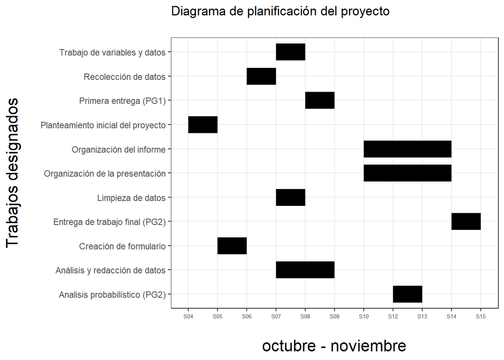

```r
data <- data.frame(Integrantes = c('Planteamiento inicial del proyecto','Creación de formulario','Recolección de datos','Trabajo de variables y datos','Limpieza de datos','Análisis y redacción de datos','Primera entrega (PG1)','Analisis probabilístico (PG2)', 'Organización del informe', 'Organización de la presentación','Entrega de trabajo final (PG2)'))
inicio = c('S04','S05','S06','S07','S07','S07','S08','S12','S10','S10','S14')
fin =    c('S05','S06','S07','S08','S08','S09','S09','S13','S14','S14','S15')

ggplot(data, aes(x=inicio, xend=fin, y=Integrantes, yend=Integrantes)) +
  theme_bw()+  geom_segment(linewidth=8) + labs(title='Diagrama de planificación del proyecto\n', x='\noctubre - noviembre', y='Trabajos designados\n') + scale_colour_manual(values = c('blue','purple','red','darkgreen')) +
  theme(axis.title = element_text(size=16))+
  theme(axis.text.x = element_text(size=5.5))+
  theme(legend.text = element_text(size=8))+
  theme(legend.title = element_text(size=0))
```

## *2. Datos*

### *2.1. Recolección de datos*

Los datos para este proyecto fueron obtenidos a través de una encuesta que se realizó en conjunción entre los miembros del equipo de trabajo y el feedback de la profesora encargada del curso. La encuesta fue creada mediante el programa **google forms**, con algunas preguntas concretas e incluidas con un contexto claro para el encuestado y otras que buscaban recolectar data precisa; se logró obtener resultados veraces y propuestos.

Para llegar a tener una buena cantidad de respuestas en nuestra muestra sacamos provecho de la virtualidad del programa en el que se diseñó la encuesta y compartimos el enlace de ésta en diversas plataformas y redes sociales. Todos los miembros del equipo tuvieron participación en este proceso.

### *2.2. Población, muestra y muestreo:*

*Población*

Se ha realizado el estudio sobre los servicios de Streaming tomando como población de estudio a un público abierto que se encuentra en un rango de edad estimado entre 18 y 100 años que cuentan con estos servicios.

*Unidad muestral*

Nuestro tamaño de muestra es de 204 observaciones, esta cantidad de observaciones es una representación de la población ya que el objetivo de estudio está enfocado en los que usen moderadamente estos servicios.

*Tipo de muestreo*

Se llevó a cabo el desarrollo de una muestra no probabilística debido a que los datos obtenidos no han sido seleccionados al azar, sino que han sido basadas en juicios subjetivos.

### *2.3. Variables:*

| **Variable** | **Tipo de variable** | **Restricciones** |
| --- | --- | --- |
| **Edad** | Numérica discreta | Número entero negativo que se encuentre fuera del rango de 18 a 100 años. |
| **Género** | Categórica nominal | Se limitó a dos opciones: femenino y masculino. |
| **Ocupación** | Categórica nominal | Se limitó a seis opciones: estudiante, trabajador independiente, trabajador dependiente, desempleado, trabaja y estudia y ninguna de las anteriores. |
| **Plataformas** | Categórica nominal | Opción múltiple limitada a siete opciones: Netflix, Amazon prime, Disney, HBO max,Star+, Hulu y otra. |
| **Escala** | Categórica ordinal | Se limitó a un rango de 1 hasta 10, siendo 1 igual a pésimo y 10 a muy bueno. |
| **Dispositivo** | Categórica nominal | Opción múltiple limitada a cinco opciones: PC, tablet, smart TV, laptop y celular. |
| **Comparte** | Categórica nominal | Se limitó a dos opciones: sí y no. |
| **Inversión** | Numérica continua | Número entero negativo que se encuentra fuera del rango de 0 a 200 soles. |
| **Finalidad** | Categórica nominal | Un string que se encuentre fuera del máximo 20 caracteres. |
| **Desventaja** | Categórica nominal | Un string que se encuentre fuera del máximo 20 caracteres. |
| **Tiempo** | Numérica discreta | Número entero negativo que se encuentre fuera del intervalo de 0 a 112 horas. |
| **Cantidad_Plataformas** | Numérica discreta | Número entero negativo que se encuentra fuera del intervalo de 1 a 25. |
| **Satisfacción** | Categórica ordinal | Opción múltiple limitada a cinco opciones: excelente, bueno, regular, deficiente e insuficiente. |
| **Suscribirse** | Categórica nominal | Se limitó a dos opciones: sí y no. |
| **Acción** | Categórica nominal | Se limitó a tres opciones: no me gusta, a veces/rara vez y frecuentemente. |
| **Drama** | Categórica nominal | Se limitó a tres opciones: no me gusta, a veces/rara vez y frecuentemente. |
| **Comedia** | Categórica nominal | Se limitó a tres opciones: no me gusta, a veces/rara vez y frecuentemente. |
| **Terror** | Categórica nominal | Se limitó a tres opciones: no me gusta, a veces/rara vez y frecuentemente. |

### *2.4. Limpieza de base de datos:*

Para comenzar, importaremos la base de datos recolectada por medio de las encuestas en modo de formulario.

```r
ISS <- read_csv("Influencia de los servicios de Streaming .csv")
```

[output not shown]

```r
View(ISS)
```

A partir de lo observado en la base de datos, procederemos a realizar lo siguiente:

1.- Encontramos la variable “Marca temporal”, la cual no consideramos relevante debido a que no nos brindan ningún dato importante destinado a analizar.

```r
colnames(ISS)
```

```
##  [1] "Marca temporal"
##  [2] "Edad\n"
##  [3] "Género"
##  [4] "Ocupación"
##  [5] "¿Cuál de estás plataformas utilizas con mayor frecuencia?\n"
##  [6] "¿Del 1 al 10 cuánto recomiendas las plataformas que utilizas ?"
##  [7] "¿Qué dispositivo utilizas usualmente para usar estas plataformas?"
##  [8] "¿Compartes cuentas de Streaming con otras personas"
##  [9] "¿Cuánto inviertes mensualmente en servicios de Streaming ?"
## [10] "¿Con qué finalidad hace uso de las plataformas de Streaming?"
## [11] "¿Alguna desventaja significativa que consideres sobre plataformas de Streaming?"
## [12] "¿Cuántas horas consideras que dedicas semanalmente a estos servicios?"
## [13] "¿Cuántas plataformas de Streaming tienes contratadas actualmente?"
## [14] "¿Cómo calificaría los servicios de Streaming con los que cuenta?"
## [15] "De acuerdo con la pregunta anterior ¿Consideraría suscribirse a más servicios de Streaming?"
## [16] "¿Qué tipo de series / películas te gustan más ? [Acción]"
## [17] "¿Qué tipo de series / películas te gustan más ? [Drama]"
## [18] "¿Qué tipo de series / películas te gustan más ? [Comedia]"
## [19] "¿Qué tipo de series / películas te gustan más ? [Terror]"
## [20] "¿Qué tipo de series / películas te gustan más ? [Documentales]"
## [21] "¿Qué tipo de series / películas te gustan más ? [Otros]"
```

Encontramos que la Marca Temporal se encuentra en la primera columna; de acuerdo a ello, procederemos a eliminarla.

```r
ISS <-ISS[,-1]
```

```r
names(ISS)
```

```
##  [1] "Edad\n"
##  [2] "Género"
##  [3] "Ocupación"
##  [4] "¿Cuál de estás plataformas utilizas con mayor frecuencia?\n"
##  [5] "¿Del 1 al 10 cuánto recomiendas las plataformas que utilizas ?"
##  [6] "¿Qué dispositivo utilizas usualmente para usar estas plataformas?"
##  [7] "¿Compartes cuentas de Streaming con otras personas"
##  [8] "¿Cuánto inviertes mensualmente en servicios de Streaming ?"
##  [9] "¿Con qué finalidad hace uso de las plataformas de Streaming?"
## [10] "¿Alguna desventaja significativa que consideres sobre plataformas de Streaming?"
## [11] "¿Cuántas horas consideras que dedicas semanalmente a estos servicios?"
## [12] "¿Cuántas plataformas de Streaming tienes contratadas actualmente?"
## [13] "¿Cómo calificaría los servicios de Streaming con los que cuenta?"
## [14] "De acuerdo con la pregunta anterior ¿Consideraría suscribirse a más servicios de Streaming?"
## [15] "¿Qué tipo de series / películas te gustan más ? [Acción]"
## [16] "¿Qué tipo de series / películas te gustan más ? [Drama]"
## [17] "¿Qué tipo de series / películas te gustan más ? [Comedia]"
## [18] "¿Qué tipo de series / películas te gustan más ? [Terror]"
## [19] "¿Qué tipo de series / películas te gustan más ? [Documentales]"
## [20] "¿Qué tipo de series / películas te gustan más ? [Otros]"
```

2.- Para un trabajo más eficiente, reduciremos el nombre de las variables que lo necesiten.

```r
ISS <- rename(ISS, Edad='Edad\n', Plataforma='¿Cuál de estás plataformas utilizas con mayor frecuencia?\n', Escala='¿Del 1 al 10 cuánto recomiendas las plataformas que utilizas ?', Dispositivo='¿Qué dispositivo utilizas usualmente para usar estas plataformas?', Comparte='¿Compartes cuentas de Streaming con otras personas',Inversión='¿Cuánto inviertes mensualmente en servicios de Streaming ?', Finalidad='¿Con qué finalidad hace uso de las plataformas de Streaming?', Desventaja='¿Alguna desventaja significativa que consideres sobre plataformas de Streaming?', Tiempo='¿Cuántas horas consideras que dedicas semanalmente a estos servicios?', Cantidad_Plataformas='¿Cuántas plataformas de Streaming tienes contratadas actualmente?', Satisfacción='¿Cómo calificaría los servicios de Streaming con los que cuenta?', Suscribirse='De acuerdo con la pregunta anterior ¿Consideraría suscribirse a más servicios de Streaming?', Accion='¿Qué tipo de series / películas te gustan más ? [Acción]', Drama='¿Qué tipo de series / películas te gustan más ? [Drama]', Comedia='¿Qué tipo de series / películas te gustan más ? [Comedia]', Terror='¿Qué tipo de series / películas te gustan más ? [Terror]', Documentales='¿Qué tipo de series / películas te gustan más ? [Documentales]', Otros='¿Qué tipo de series / películas te gustan más ? [Otros]')
names(ISS)
```

```
##  [1] "Edad"                 "Género"               "Ocupación"
##  [4] "Plataforma"           "Escala"               "Dispositivo"
##  [7] "Comparte"             "Inversión"            "Finalidad"
## [10] "Desventaja"           "Tiempo"               "Cantidad_Plataformas"
## [13] "Satisfacción"         "Suscribirse"          "Accion"
## [16] "Drama"                "Comedia"              "Terror"
## [19] "Documentales"         "Otros"
```

3.- Verificación de variables

- Nos ubicamos en la variable *“Finalidad”* y encontramos una gran variedad de datos que pertenecen a una misma categoría pero separados debido a errores ortográficos de los mismos, por ello se procede a agruparlos a una misma categoría.

```r
table(ISS$Finalidad)
```

```
##
##                    0                   50           Casi nunca
##                    2                    1                    1
##              Deporte          Diariamente          Distraccion
##                    1                    1                    1
##          Distracción           Distraerme            Diversion
##                    4                    1                    3
##            diversión            Diversión  Diversión y estudio
##                    1                    4                    1
##        Entertainment        Entranamuento        entrenamiento
##                    1                    1                    2
##        Entrenamiento        Entrenimiento           Entretener
##                    5                    2                    1
##         Entretenerme     Entretenimiemnto      entretenimiento
##                    1                    1                   12
##      Entretenimiento     Entretenimientos      Escuchar música
##                  125                    2                    1
##          Informatico          INTERDIARIO                 Nada
##                    1                    1                    1
##              Ninguna                No sé               No uso
##                    1                    1                    1
##           no uso ;-;          No utilizo.    Ocio y pasatiempo
##                    1                    1                    1
##     Para distracción    para entretenerme      Para informarme
##                    1                    1                    1
## Para pasar el tiempo        Pasar el rato      Pasar el tiempo
##                    1                    2                    2
##           Pasatiempo            Películas           Relajacion
##                    1                    1                    1
##         Relajamiento            Relajarme   series y peliculas
##                    1                    3                    1
##               Tiktok              Trabajo              Variado
##                    1                    1                    1
##                    X
##                    1
```

- Continuamos con la limpieza y llegamos a la variable *“Desventaja”* donde se presenta el mismo tipo de error con respecto a la ortografía; según a esto se agruparán los datos respectivos.

```r
table(ISS$Desventaja)
```

```
##
##                    -                    .         Aburrimiento
##                    1                    1                    1
##        Aburrrimeinto             Adicción   Adicción de series
##                    1                    3                    1
##         Baja calidad              Calidad       Conexión lenta
##                    1                    1                    1
##    Consume mi tiempo       Consume tiempo                costo
##                    1                    1                    1
##                Costo            Costumbre          Dependencia
##                    1                    1                    1
##      desconcentrarme            Desestres  Desgastar el tiempo
##                    1                    1                    1
##              Devaneo               Dinero          distraccion
##                    1                    1                    2
##          Distraccion          distracción          Distracción
##                   17                    6                   64
##        Distracciones           Distracion              Distrae
##                    2                    1                    1
##             Distraer           Distraerse            Diversion
##                    1                    1                    1
##            Educación      Entretenimiento   Es gasto adicional
##                    1                    1                    1
##     estres acumulado             Lentitud             limitado
##                    1                    1                    1
##     Malos subtitulos        Más contenido  Más pagos y limites
##                    1                    1                    1
##   Me distraigo mucho    mmm distraerme x2          Mucho vicio
##                    1                    1                    1
##              Ninguna              Ninguno                   no
##                   14                    2                    1
##                   No No comparte pantalla      No duermo mucho
##                    3                    1                    1
##      No hay variedad No poder dormir bien                No se
##                    1                    1                    1
##   No tiene cartelera               No uso                NOHAY
##                    2                    1                    1
##                 Ocio       Olvidar tareas         optimización
##                    2                    1                    1
##                 Pago     perder el tiempo        Perder tiempo
##                    1                    1                    1
##    Perdida de tiempo    PERDIDA DE TIEMPO    Pérdida de tiempo
##                    3                    1                    3
##   Pérdida de tiempo.       Poca variedad.        Poco catálogo
##                    1                    1                    1
##         Poco control               Precio       Procastinacion
##                    1                    1                    2
##          Procastinar      Procrastinación         Procrastinar
##                    1                    1                    1
## Puro cine 🚬  Quitan mucho tiempo  Reducción de tiempo
##                    1                    1                    1
##   Requiere de tiempo   se gasta y distrae Secuencia incompleta
##                    1                    1                    1
##         Sedentarismo                   Si            Su precio
##                    3                    1                    1
##               Tiempo Tiempo desperdiciado             Usuarios
##                    1                    1                    1
##    Variedad límitada                vicio                Vicio
##                    1                    1                    4
##                   Xx
##                    1
```

El proceso de elaboración de las preguntas para la recolección de datos pasó por varias revisiones para evitar tener varios datos incorrectos por lo que se limitó a dos variables con respuesta libre; como se observó en las variables *“Finalidad” y “Desventaja”*, se presentaron datos muy variados por parte de la muestra de la población, por lo que se modificarán y agruparán los datos variados en uno solo, este proceso será parte de la limpieza de la base de datos.

- Se presentan una poca visualización de otras respuestas debido al largo nombre de la opción *Amazon Prime Video*, por lo que se modificará su denominación como *Amazon*.

```r
ISS %>% mutate(Plataforma =
                 ifelse(Plataforma =="Amazon Prime Video","Amazon", Plataforma))->ISS
```

```r
ISS %>% mutate(Finalidad =
                ifelse(Finalidad =="0","Ninguna",
                ifelse(Finalidad =="50","Ninguna",
ifelse(Finalidad =="Casi nunca","Ninguna",
ifelse(Finalidad =="Diariamente","Ninguna",
ifelse(Finalidad =="INTERDIARIO","Ninguna",
ifelse(Finalidad =="Nada","Ninguna",
ifelse(Finalidad =="No utilizo","Ninguna",
ifelse(Finalidad =="No utilizo.","Ninguna",
ifelse(Finalidad =="no uso","Ninguna",
ifelse(Finalidad =="No uso","Ninguna",
ifelse(Finalidad =="No sé","Ninguna",
ifelse(Finalidad =="Tiktok","Ninguna",
ifelse(Finalidad =="Variado","Ninguna",
ifelse(Finalidad =="no uso ;-;","Ninguna",
ifelse(Finalidad =="X","Ninguna", Finalidad))))))))))))))))->ISS
```

```r
ISS %>% mutate(Finalidad =
ifelse(Finalidad =="Entertainment","Entretenimiento",
ifelse(Finalidad =="entretenimiento","Entretenimiento",
ifelse(Finalidad =="Entretenimientos","Entretenimiento",
ifelse(Finalidad =="entrenamiento","Entretenimiento",
ifelse(Finalidad =="Entretenerme","Entretenimiento",
ifelse(Finalidad =="para entretenerme","Entretenimiento",
ifelse(Finalidad =="Entrenamiento","Entretenimiento",
ifelse(Finalidad =="Entrenimiento","Entretenimiento",
ifelse(Finalidad =="Entrenamiento","Entretenimiento",
ifelse(Finalidad =="Pasar el rato","Entretenimiento",
ifelse(Finalidad =="Para distracción","Entretenimiento",
ifelse(Finalidad =="Entretener","Entretenimiento",
ifelse(Finalidad =="Ocio y pasatiempo","Entretenimiento",
ifelse(Finalidad =="Deporte","Entretenimiento",
ifelse(Finalidad =="series y peliculas","Entretenimiento",
ifelse(Finalidad =="Para informarme","Entretenimiento",
ifelse(Finalidad =="Pasatiempo","Entretenimiento",
ifelse(Finalidad =="Pasar el tiempo","Entretenimiento",
ifelse(Finalidad =="diversión","Entretenimiento",
ifelse(Finalidad =="Películas","Entretenimiento",
ifelse(Finalidad =="Distraccion","Entretenimiento",
ifelse(Finalidad =="Escuchar música","Entretenimiento",
ifelse(Finalidad =="Para pasar el tiempo","Entretenimiento",
ifelse(Finalidad =="Relajacion","Entretenimiento",
ifelse(Finalidad =="Diversion","Entretenimiento",
ifelse(Finalidad =="Distracción","Entretenimiento",
ifelse(Finalidad =="Diversión y estudio","Entretenimiento",
ifelse(Finalidad =="para entretenerme","Entretenimiento",
ifelse(Finalidad =="Entranamuento","Entretenimiento",
ifelse(Finalidad =="Entretenimiemnto","Entretenimiento",
ifelse(Finalidad =="Trabajo","Entretenimiento",
ifelse(Finalidad =="Diversión","Entretenimiento",
ifelse(Finalidad =="Distraerme","Entretenimiento",
ifelse(Finalidad =="Relajamiento","Entretenimiento",
ifelse(Finalidad =="Informatico","Entretenimiento", Finalidad))))))))))))))))))))))))))))))))))))->ISS
```

```r
ISS %>% mutate(Desventaja =
                ifelse(Desventaja =="-","Ninguna",
                ifelse(Desventaja ==".","Ninguna",
ifelse(Desventaja =="Ninguno","Ninguna",
ifelse(Desventaja =="no","Ninguna",
ifelse(Desventaja =="No","Ninguna",
ifelse(Desventaja =="NOHAY","Ninguna",
ifelse(Desventaja =="No uso","Ninguna",
ifelse(Desventaja =="No se","Ninguna",
ifelse(Desventaja =="Puro cine 🚬","Ninguna",
ifelse(Desventaja =="Sí","Ninguna",
ifelse(Desventaja =="Si","Ninguna",
ifelse(Desventaja =="Tiktok","Ninguna",
ifelse(Desventaja =="Xx","Ninguna", Desventaja))))))))))))))->ISS
```

```r
ISS %>% mutate(Desventaja =
                ifelse(Desventaja =="costo","Sobre pagos",
                ifelse(Desventaja =="Costo","Sobre pagos",
ifelse(Desventaja =="Dinero","Sobre pagos",
ifelse(Desventaja =="Es gasto adicional","Sobre pagos",
ifelse(Desventaja =="Más pagos y limites","Sobre pagos",
ifelse(Desventaja =="Pago","Sobre pagos",
ifelse(Desventaja =="Precio","Sobre pagos",
ifelse(Desventaja =="Su precio","Sobre pagos",
ifelse(Desventaja =="se gasta y distrae","Sobre pagos",
ifelse(Desventaja =="Su precio.","Sobre pagos",
ifelse(Desventaja =="Desestres","Distracción",
ifelse(Desventaja =="distraccion","Distracción",
ifelse(Desventaja =="Distraccion","Distracción",
ifelse(Desventaja =="Distraer","Distracción",
ifelse(Desventaja =="Distrae","Distracción",
ifelse(Desventaja =="Distracion","Distracción",
ifelse(Desventaja =="Distracciones","Distracción",
ifelse(Desventaja =="distracción","Distracción",
ifelse(Desventaja =="Me distraigo mucho","Distracción",
ifelse(Desventaja =="estres acumulado","Distracción",
ifelse(Desventaja =="Entretenimiento","Distracción",
ifelse(Desventaja =="Educación","Distracción",
ifelse(Desventaja =="Diversion","Distracción",
ifelse(Desventaja =="Distraerse","Distracción",
ifelse(Desventaja =="mmm distraerme x2","Distracción",
ifelse(Desventaja =="Ocio","Distracción",
ifelse(Desventaja =="Olvidar tareas","Distracción",
ifelse(Desventaja =="Consume mi tiempo","Consumo de tiempo",
ifelse(Desventaja =="Consume tiempo","Consumo de tiempo",
ifelse(Desventaja =="Desgastar el tiempo","Consumo de tiempo",
ifelse(Desventaja =="PERDIDA DE TIEMPO","Consumo de tiempo",
ifelse(Desventaja =="Perdida de tiempo","Consumo de tiempo",
ifelse(Desventaja =="Perder tiempo","Consumo de tiempo",
ifelse(Desventaja =="perder el tiempo","Consumo de tiempo",
ifelse(Desventaja =="Pérdida de tiempo","Consumo de tiempo",
ifelse(Desventaja =="Pérdida de tiempo.","Consumo de tiempo",
ifelse(Desventaja =="Quitan mucho tiempo","Consumo de tiempo",
ifelse(Desventaja =="Requiere de tiempo","Consumo de tiempo",
ifelse(Desventaja =="Reducción de tiempo","Consumo de tiempo",
ifelse(Desventaja =="Tiempo","Consumo de tiempo",
ifelse(Desventaja =="Tiempo desperdiciado","Consumo de tiempo",
ifelse(Desventaja =="Baja calidad","Problema de plataforma",
ifelse(Desventaja =="Calidad","Problema de plataforma",
ifelse(Desventaja =="Conexión lenta","Problema de plataforma",
ifelse(Desventaja =="limitado","Problema de plataforma",
ifelse(Desventaja =="Lentitud","Problema de plataforma",
ifelse(Desventaja =="Malos subtitulos","Problema de plataforma",
ifelse(Desventaja =="Más contenido","Problema de plataforma",Desventaja)))))))))))))))))))))))))))))))))))))))))))))))))->ISS
```

```r
ISS %>% mutate(Desventaja =
                      ifelse(Desventaja =="No comparte pantalla","Problema de plataforma",
ifelse(Desventaja =="optimización","Problema de plataforma",
ifelse(Desventaja =="No tiene cartelera","Problema de plataforma",
ifelse(Desventaja =="No hay variedad","Problema de plataforma",
ifelse(Desventaja =="Poca variedad.","Problema de plataforma",
ifelse(Desventaja =="Secuencia incompleta","Problema de plataforma",
ifelse(Desventaja =="Variedad límitada","Problema de plataforma",
ifelse(Desventaja =="Usuarios","Problema de plataforma",
ifelse(Desventaja =="Poco catálogo","Problema de plataforma",
ifelse(Desventaja =="Adicción de series","Adicción",
ifelse(Desventaja =="desconcentrarme","Adicción",
ifelse(Desventaja =="Dependencia","Adicción",
ifelse(Desventaja =="Costumbre","Adicción",
ifelse(Desventaja =="Devaneo","Adicción",
ifelse(Desventaja =="Mucho vicio","Adicción",
ifelse(Desventaja =="Procastinacion","Adicción",
ifelse(Desventaja =="Procastinar","Adicción",
ifelse(Desventaja =="Procrastinación","Adicción",
ifelse(Desventaja =="Procrastinar","Adicción",
ifelse(Desventaja =="Vicio","Adicción",
ifelse(Desventaja =="Poco control","Adicción",
ifelse(Desventaja =="Sedentarismo","Adicción",
ifelse(Desventaja =="Adcción","Adicción",
ifelse(Desventaja =="vicio","Adicción",
ifelse(Desventaja =="Aburrrimeinto","Aburrimiento",
ifelse(Desventaja =="No poder dormir bien","Problema al dormir",
ifelse(Desventaja =="No duermo mucho","Problema al dormir",Desventaja))))))))))))))))))))))))))))->ISS
```

## *3. Análisis descriptivo*

### *3.1. Edad*

Comenzamos con la variable *Edad* para analizar entre qué intervalos de edad hay más uso o suscripción con respecto a las plataformas de Streaming.

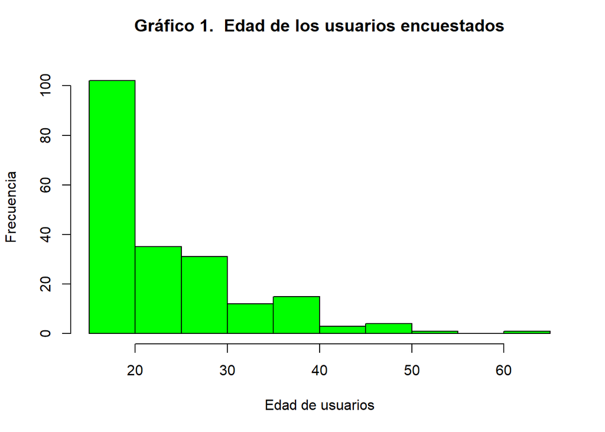

```r
hist(ISS$Edad, main="Gráfico 1.  Edad de los usuarios encuestados\n", xlab="Edad de usuarios", ylab="Frecuencia", col="green", breaks= 15)
```

A partir de la tabla sobre las edades de la unidad muestral, se observa que hay más uso o suscripción entre personas de 18 y 21 años.

### **Descriptor numérico:**

```r
cat('Número de casos completos de la variable "Edad":', sum(complete.cases(ISS$Edad)))
```

```
## Número de casos completos de la variable "Edad": 204
```

Con respecto al análisis anterior, se observa 204 casos completos de la variable edad y por esta razón la muestra selectiva de estudio de esta variable será de 204 observaciones.

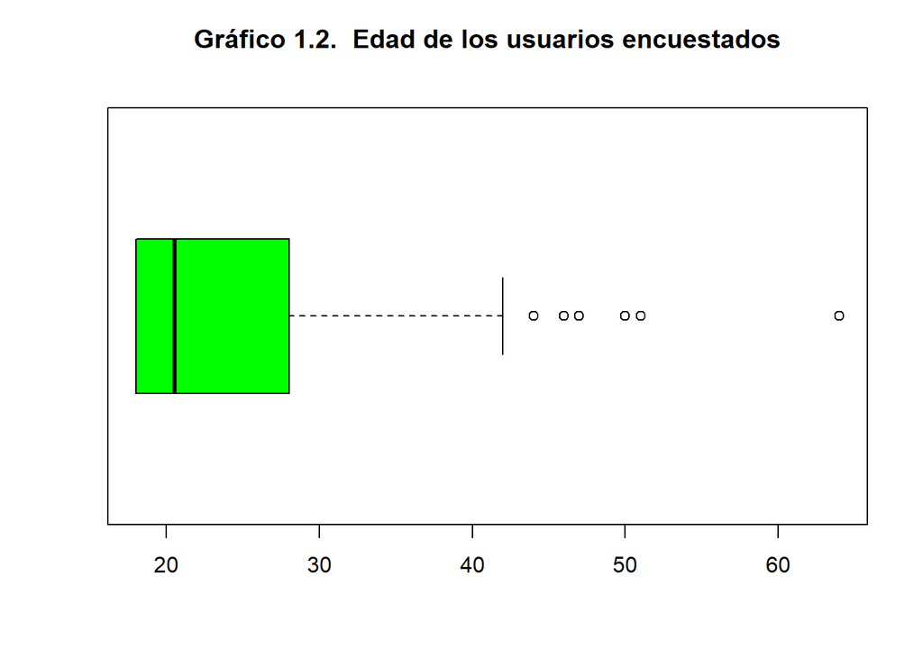

```r
boxplot(ISS$Edad, horizontal = TRUE, main="Gráfico 1.2.  Edad de los usuarios encuestados\n", col="green")
```

Se observa la presencia de datos atípicos, por lo menos la presencia de 1, ya que se está trabajando con un público abierto de rango entre 18 y 100 años, donde sí habrán diferencias amplias de edad. Según a lo anterior, no se determinará la **media, varianza, desviación estándar y coeficiente de varianza** de los datos, ya que obtendríamos un valor no representativo de la población.

*- Mediana*

```r
cat('Mediana de la variable "Edad":', round(median(ISS$Edad, na.rm=TRUE)))
```

```
## Mediana de la variable "Edad": 20
```

*- Moda*

```r
cat('Moda de la variable "Edad":', mfv(ISS$Edad))
```

```
## Moda de la variable "Edad": 18
```

*- Rango*

```r
range(ISS$Edad, na.rm = TRUE)
```

```
## [1] 18 64
```

### *3.2. Género*

En la variable *Género* se recolectaron datos tanto sobre qué género hace más uso de las plataformas de Streaming como la participación en el estudio para así determinar el reflejo del género presente en el estudio. A partir de lo indicado se obtuvieron los siguientes datos:

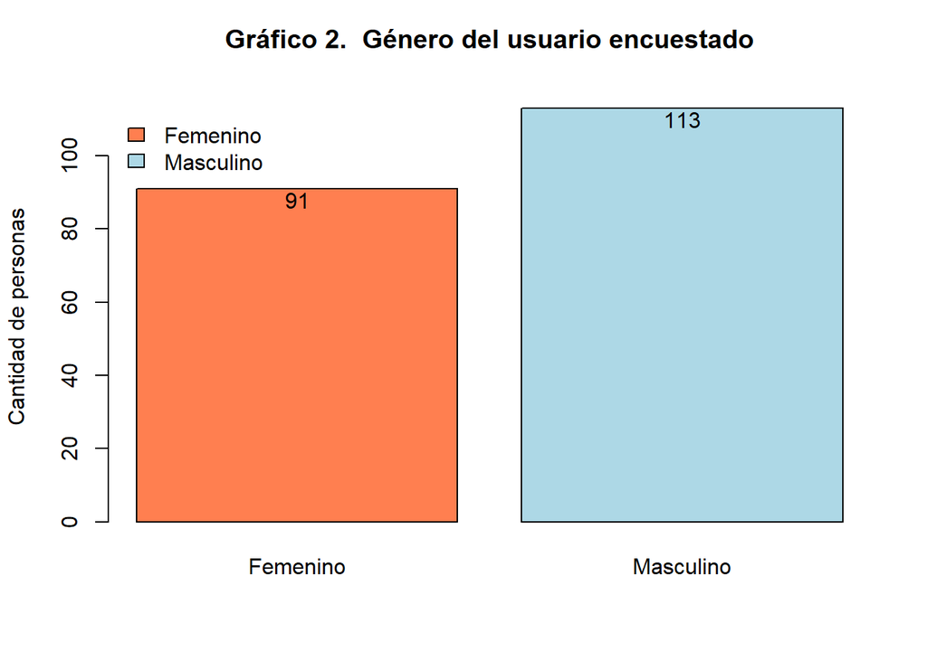

```r
G_Genero<-table(ISS$Género)
barp<-barplot(G_Genero,main = "Gráfico 2.  Género del usuario encuestado\n", ylab='Cantidad de personas',col = c("coral", "lightblue"))
text(barp, G_Genero-3, labels = G_Genero)

legend('topleft', legend=rownames(G_Genero), bty='n',fill=c("coral", "lightblue"))
```

```r
cat('Número de casos completos de la variable "Género": ', nrow(ISS),"\n")
```

```
## Número de casos completos de la variable "Género":  204
```

```r
table(ISS$Género)
```

```
##
##  Femenino Masculino
##        91       113
```

```r
cat("\n")
```

```r
cat('Moda de la variable "Género":', mfv(ISS$Género) ,'\n')
```

```
## Moda de la variable "Género": Masculino
```

Consideramos el número de observaciones mediante el conteo de datos de la variable, además la variable es de tipo *cualitativa*. De acuerdo con lo anterior, se evidencia una mayor cantidad de participación por parte del género masculino donde se puede deducir que la encuesta llegó a más varones que respecto que a mujeres.

### *3.3. Ocupación*

En la variable *Ocupación* se recolectaron datos sobre la ocupación del usuario. A partir de lo indicado se obtuvieron los siguientes datos:

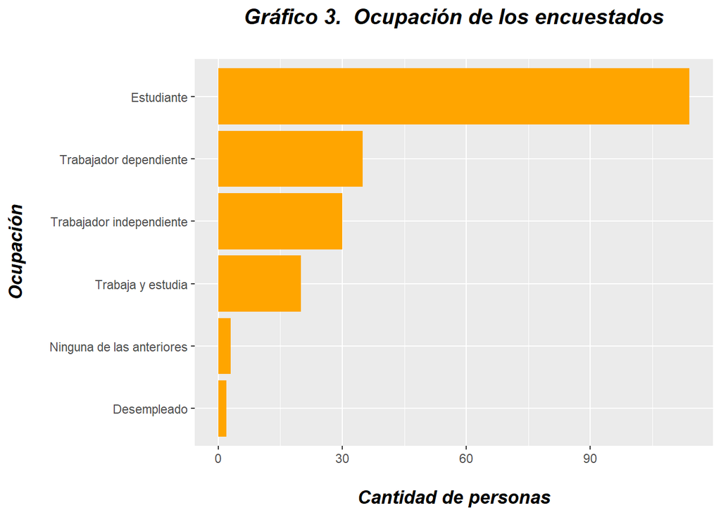

```r
ggplot(ISS) +
  aes(x =reorder(Ocupación,Ocupación,function(x)+length(x))) +
  geom_bar(fill = "orange") +
  labs(
    x = "Ocupación\n",
    y = "\nCantidad de personas",
    title = "Gráfico 3.  Ocupación de los encuestados\n"
  ) +
  coord_flip() +
  theme_gray() +
  theme(
    plot.title = element_text(size = 15L,
    face = "bold.italic",
    hjust = 0.5),
    axis.title.y = element_text(size = 13L,
    face = "bold.italic"),
    axis.title.x = element_text(size = 13L,
    face = "bold.italic")

  )
```

A partir de la tabla sobre las ocupaciones de la unidad muestral, se observa una mayor participación de estudiantes en el estudio; sin embargo, en este punto no se puede determinar aspectos como el uso de las plataformas o si existe alguna inversión de por medio. Asimismo, en la frecuencia más baja tenemos a las personas desempleadas.

```r
table(ISS$Ocupación)
```

```
##
##               Desempleado                Estudiante Ninguna de las anteriores
##                         2                       114                         3
##         Trabaja y estudia    Trabajador dependiente  Trabajador independiente
##                        20                        35                        30
```

Analizamos la cantidad de personas por cada ocupación, complementando la *gráfica 3*, y damos con datos extra con respecto a cada ocupación de la muestra:

```r
cat('Número de casos completos de la variable "Ocupación":', sum(complete.cases(ISS$Ocupación)),'\n')
```

```
## Número de casos completos de la variable "Ocupación": 204
```

```r
cat('Moda de la variable "Ocupación":', mfv(ISS$Ocupación))
```

```
## Moda de la variable "Ocupación": Estudiante
```

De acuerdo a la tabla de frecuencia sobre la ocupación de las personas encuestadas; se observa que a pesar de contar con un rango amplio de edad, hubo mayor cantidad de estudiantes y una menor participación de personas desempleadas.

### *3.4. Plataformas*

En la variable *Plataforma* se recolectaron datos sobre cuál es la plataforma de Streaming más consumida por los encuestados. A partir de lo indicado se obtuvieron los siguientes datos:

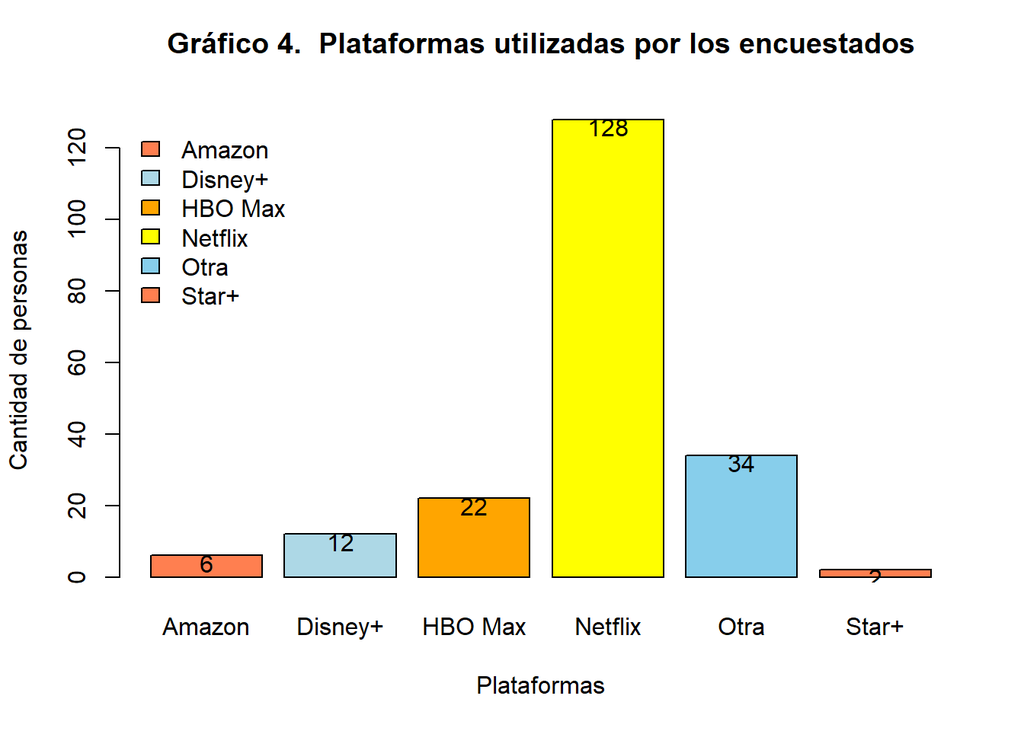

```r
P_Plataforma<-table(ISS$Plataforma)
barp<-barplot(P_Plataforma, main = "Gráfico 4.  Plataformas utilizadas por los encuestados\n", ylab='Cantidad de personas', xlab='Plataformas',col = c("coral", "lightblue","orange","yellow","skyblue"))
text(barp, P_Plataforma-2, labels = P_Plataforma)

legend('topleft', legend=rownames(P_Plataforma), bty='n',fill=c("coral", "lightblue","orange","yellow","skyblue"))
```

```r
table(ISS$Plataforma)
```

```
##
##  Amazon Disney+ HBO Max Netflix    Otra   Star+
##       6      12      22     128      34       2
```

```r
cat('Número de casos completos de la variable "Plataformas":', sum(complete.cases(ISS$Plataforma)),'\n')
```

```
## Número de casos completos de la variable "Plataformas": 204
```

```r
cat("\n")
```

```r
cat('Moda de la variable "Plataformas":', mfv(ISS$Plataforma),"\n")
```

```
## Moda de la variable "Plataformas": Netflix
```

```r
cat("\n")
```

```r
cat("Cantidad de observaciones con", mfv(ISS$Plataforma) , ": ",sum(ISS$Plataforma=="Netflix"))
```

```
## Cantidad de observaciones con Netflix :  128
```

A partir de la tabla y el gráfico 4, sobre las plataformas de la unidad muestral, se observa que en primer lugar está Netflix; segundo, otras plataformas; tercero, HBO Max; cuarto, Disney+; quinto, Amazon Prime Video y por último Star+; así logrando ser Netflix la plataforma con más uso por el usuario. Según los descriptores, se observa que hay un total de 204 casos completos (no se encuentra ningún dato vacío), y que el dato más frecuente es *Netflix*, por ello se concluye que hay más personas que utilizan dicha plataforma; con un total de 128 personas.

### *3.5. Escala*

En la variable *Escala* se recolectaron datos sobre la calidad del servicio de Streaming que se utiliza con mayor frecuencia. A partir de lo indicado se obtuvieron los siguientes datos:

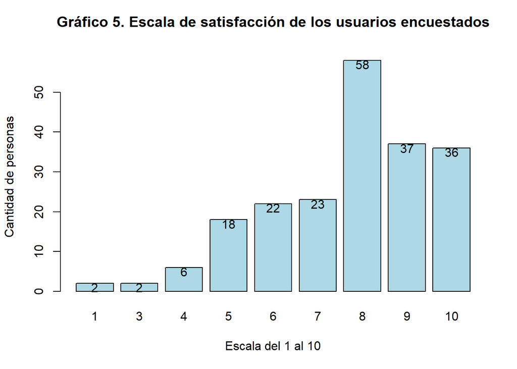

```r
E_escala<-table(ISS$Escala)
barp<-barplot(E_escala,main = "Gráfico 5. Escala de satisfacción de los usuarios encuestados\n", ylab='Cantidad de personas', xlab='Escala del 1 al 10',col = c("lightblue"))
text(barp, E_escala-1, labels = E_escala)
```

```r
cat('Número de casos completos de la variable "Escala":', sum(complete.cases(ISS$Plataforma)),'\n')
```

```
## Número de casos completos de la variable "Escala": 204
```

```r
cat('Moda de la variable "Escala":', mfv(ISS$Escala), median(ISS$Escala))
```

```
## Moda de la variable "Escala": 8 8
```

A partir de la tabla sobre las escalas de la unidad muestral, se observa que en la escala del 1 al 10, la votación más alta fue 8 con un total de 58 personas, así mismo se presentó 2 personas con una escala de 1 y de 3, es decir que en la escala 8 las personas se sienten conforme con sus plataformas mientras que las personas de escala 1 y 3 se sienten inconformes.

### *3.6. Dispositivo*

En la variable *Dispositivo* se recolectaron datos sobre los dispositivos que utiliza con mayor frecuencia para el uso de estas plataformas. A partir de lo indicado se obtuvieron los siguientes datos:

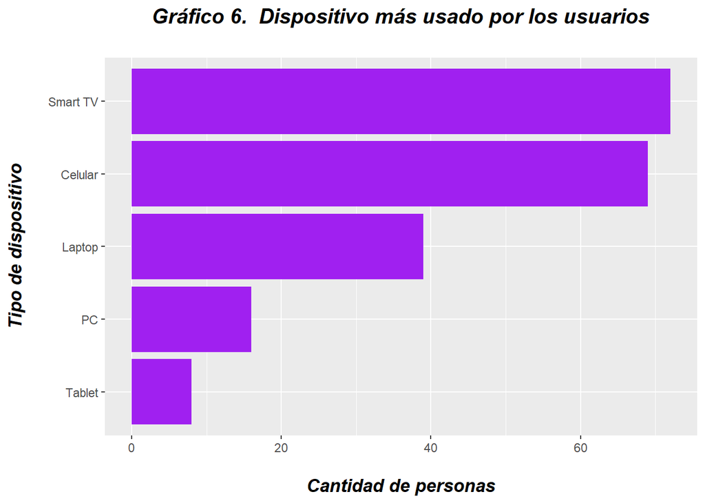

```r
ggplot(ISS) +
  aes(x =reorder(Dispositivo,Dispositivo,function(x)+length(x))) +
  geom_bar(fill = "purple") +
  labs(
    x = "Tipo de dispositivo\n",
    y = "\nCantidad de personas",
    title = "Gráfico 6.  Dispositivo más usado por los usuarios\n"
  ) +
  coord_flip() +
  theme_gray() +
  theme(
    plot.title = element_text(size = 15L,
    face = "bold.italic",
    hjust = 0.5),
    axis.title.y = element_text(size = 13L,
    face = "bold.italic"),
    axis.title.x = element_text(size = 13L,
    face = "bold.italic")
  )
```

A partir del gráfico 6 sobre los dispositivos de la unidad muestral, se observa que el dispositivo más usado por el usuario en las plataformas de Streaming son los Smart TV´s, mientras que el dispositivo menos usado son las tablet´s.

### *Descriptor numérico:*

```r
cat('Número de casos completos de la variable "Dispositivo":', nrow(ISS),"\n")
```

```
## Número de casos completos de la variable "Dispositivo": 204
```

```r
table(ISS$Dispositivo)
```

```
##
##  Celular   Laptop       PC Smart TV   Tablet
##       69       39       16       72        8
```

```r
cat("\n")
```

```r
cat('Moda de la variable "Dispositivo":', mfv(ISS$Dispositivo) ,'\n')
```

```
## Moda de la variable "Dispositivo": Smart TV
```

Se observa un total de 204 observaciones (no se encuentra ningún dato vacío) y que, según la tabla, con un total de 72 datos encontrados, el *Smart TV* es el dispositivo más usado; mientras que, con un total de 8 datos encontrados, la *tablet* es el dispositivo menos usado por las personas encuestadas.

### *3.7. Comparte*

En la variable *Comparte* se recolectaron datos sobre los usuarios que comparten mas de una plataforma. A partir de lo indicado se obtuvieron los siguientes datos:

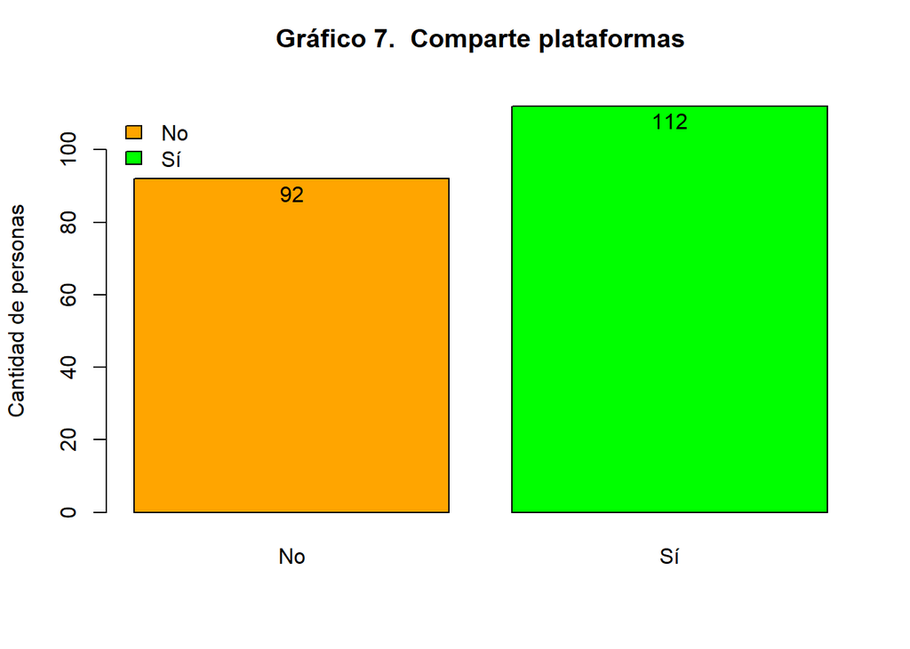

```r
C_comparte<-table(ISS$Comparte)
barp<-barplot(C_comparte,main = "Gráfico 7.  Comparte plataformas\n", xlab='', ylab='Cantidad de personas',col = c("orange", "green"))
text(barp, C_comparte-4, labels = C_comparte)

legend('topleft', legend=rownames(C_comparte), bty='n',fill=c("orange", "green"))
```

```r
unique(ISS$Comparte)
```

```
## [1] "Sí" "No"
```

```r
C_SI <- filter(ISS, Comparte == "Sí")
C_NO <- filter(ISS, Comparte == "No")
cat('Número de observaciones de la variable "Comparte":', sum(complete.cases(ISS$Comparte)), "\n")
```

```
## Número de observaciones de la variable "Comparte": 204
```

```r
cat("Número de personas que sí comparten plataformas:", nrow(C_SI),"\n")
```

```
## Número de personas que sí comparten plataformas: 112
```

```r
cat("Número de personas que no comparten plataformas:", nrow(C_NO),"\n")
```

```
## Número de personas que no comparten plataformas: 92
```

```r
cat("Diferencia de encuestados(as):", nrow(C_SI)-nrow(C_NO))
```

```
## Diferencia de encuestados(as): 20
```

De acuerdo al *gráfico 7* y a los descriptores, se observan 204 observaciones (no se encuentra ningún dato vacío) y que se dividen en que si las personas encuestados comparten o no sus servicios de streaming; donde 112 personas **sí** comparten mientras que 92 personas **no** lo hacen. De acuerdo a lo anterior, se evidencia una diferencia de 20 personas entre las que comparten con las que no.

### *3.8. Inversión*

En la variable *Inversión* se recolectaron datos sobre cual es el presupuesto que invierten los usuarios en las plataformas de streaming. A partir de lo indicado se obtuvieron los siguientes datos:

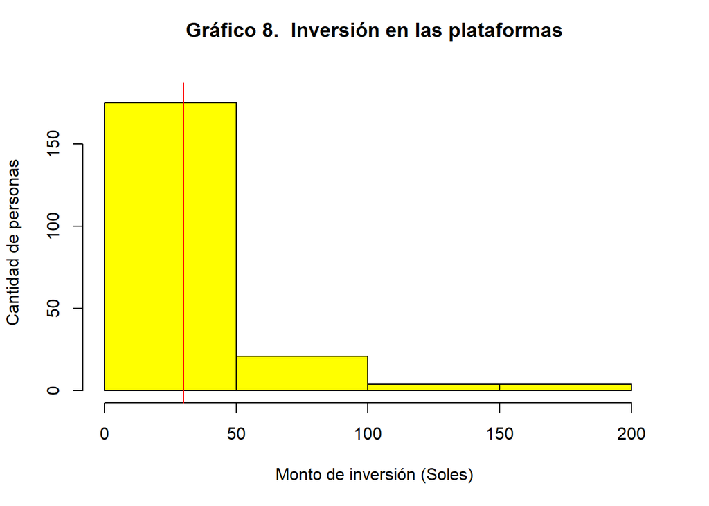

```r
hist(ISS$Inversión, main = "Gráfico 8.  Inversión en las plataformas\n", xlab = "Monto de inversión (Soles)", ylab = "Cantidad de personas", breaks=5,col = "YELLOW", border = "black", xlim = c(0, 205), ylim = c(0, 180))
abline(v=median(ISS$Inversión), col="red")
```

### *Descriptor numérico:*

```r
cat('Número de observaciones de la variable "Inversión":', sum(complete.cases(ISS$Inversión)))
```

```
## Número de observaciones de la variable "Inversión": 204
```

Con respecto al análisis anterior, se observa 204 casos completos de la variable *Inversión* y por esta razón la muestra selectiva de estudio de esta variable será de 204 observaciones.

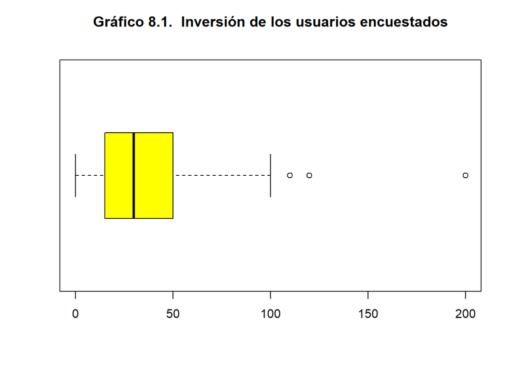

```r
boxplot(ISS$Inversión, horizontal = TRUE, main="Gráfico 8.1.  Inversión de los usuarios encuestados\n", col="yellow")
```

Se observa la presencia de datos atípicos, por lo menos la presencia de 3 datos atípicos, ya que se está trabajando con un cantidades enteras entre 0 y 200 soles, donde sí habrá presencia de diferencias amplias de inversión. Según a lo anterior, no se determinará la **media, varianza, desviación estándar y coeficiente de varianza** de los datos ya que obtendríamos un valor no representativo de la población.

*- Mediana*

```r
cat('Mediana de la variable "Inversión":', round(median(ISS$Inversión, na.rm=TRUE)))
```

```
## Mediana de la variable "Inversión": 30
```

*- Moda*

```r
cat('Moda de la variable "Inversión":', mfv(ISS$Inversión))
```

```
## Moda de la variable "Inversión": 30 50
```

*- Rango*

```r
range(ISS$Inversión, na.rm = TRUE)
```

```
## [1]   0 200
```

### *3.9. Finalidad*

En la variable *Finalidad* se recolectaron datos sobre cual es el objetivo por que el usuario utiliza las plataformas de Streaming. A partir de lo indicado se obtuvieron los siguientes datos:

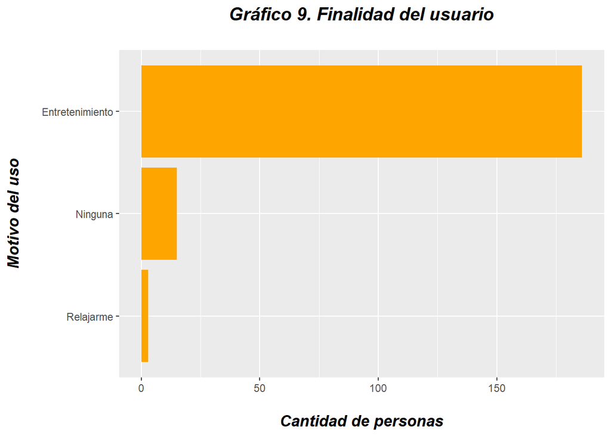

```r
ggplot(ISS) +
  aes(x =reorder(Finalidad,Finalidad,function(x)+length(x))) +
  geom_bar(fill = "orange") +
  labs(
    x = "Motivo del uso\n",
    y = "\nCantidad de personas",
    title = "Gráfico 9. Finalidad del usuario\n"
  ) +
  coord_flip() +
  theme_gray() +
  theme(
    plot.title = element_text(size = 15L,
    face = "bold.italic",
    hjust = 0.5),
    axis.title.y = element_text(size = 13L,
    face = "bold.italic"),
    axis.title.x = element_text(size = 13L,
    face = "bold.italic")
  )
```

### *Descriptor numérico:*

```r
cat('Número de observaciones de la variable "Finalidad":', sum(complete.cases(ISS$Finalidad)))
```

```
## Número de observaciones de la variable "Finalidad": 204
```

*- Moda*

```r
cat('Moda de la variable "Finalidad":', mfv(ISS$Finalidad))
```

```
## Moda de la variable "Finalidad": Entretenimiento
```

```r
unique(ISS$Finalidad)
```

```
## [1] "Entretenimiento" "Relajarme"       "Ninguna"
```

```r
FINA <- filter(ISS, Finalidad == "Entretenimiento")
cat("Número de personas con finalidad de Entretenimiento:", nrow(FINA),"\n")
```

```
## Número de personas con finalidad de Entretenimiento: 186
```

A partir del gráfico y la tabla descriptiva sobre las finalidades de la unidad muestral, se observa que un total de 204 observaciones (no se encuentra ningún dato vacío) y que el objetivo principal, por el cual los usuarios utilizan estas plataformas, es el entretenimiento; con un total de 186 personas.

### *3.10. Desventaja*

En la variable *Desventaja* se recolectaron datos sobre las desventajas que puede presentarse. A partir de lo indicado se obtuvieron los siguientes datos:

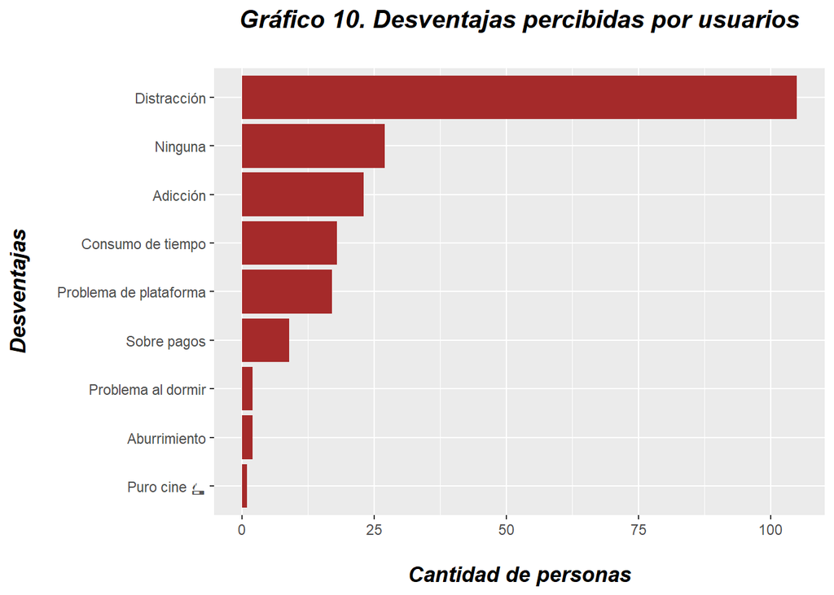

```r
ggplot(ISS) +
    aes(x =reorder(Desventaja,Desventaja,function(x)+length(x))) +
  geom_bar(fill = "brown") +
  labs(
    x = "Desventajas\n",
    y = "\nCantidad de personas",
    title = "Gráfico 10. Desventajas percibidas por usuarios\n"
  ) +
  coord_flip() +
  theme_gray() +
  theme(
    plot.title = element_text(size = 15L,
    face = "bold.italic",
    hjust = 0.5),
    axis.title.y = element_text(size = 13L,
    face = "bold.italic"),
    axis.title.x = element_text(size = 13L,
    face = "bold.italic")
  )
```

### *Descriptor numérico:*

```r
cat('Número de observaciones de la variable "Desventaja":', sum(complete.cases(ISS$Finalidad)))
```

```
## Número de observaciones de la variable "Desventaja": 204
```

```r
cat('Moda de la variable "Desventaja":', mfv(ISS$Desventaja))
```

```
## Moda de la variable "Desventaja": Distracción
```

```r
unique(ISS$Desventaja)
```

```
## [1] "Distracción"            "Consumo de tiempo"      "Adicción"
## [4] "Ninguna"                "Problema de plataforma" "Puro cine 🚬"
## [7] "Sobre pagos"            "Problema al dormir"     "Aburrimiento"
```

```r
DESV <- filter(ISS, Desventaja == "Distracción")
cat("Número de personas que consideran la Distracción como una desventaja:", nrow(DESV),"\n")
```

```
## Número de personas que consideran la Distracción como una desventaja: 105
```

A partir del gráfico y la tabla descriptiva sobre las desventajas que considera la unidad muestral, se observa que un total de 204 observaciones (no se encuentra ningún dato vacío) y que el punto perjuicioso, el cual los usuarios lo consideran como aspecto negativo, es la distracción; con un total de 105 personas.

### *3.11. Tiempo*

En la variable *Tiempo* se recolectaron datos sobre el número de horas que consumen los encuestados en las plataformas de streaming. A partir de lo indicado se obtuvieron los siguientes datos:

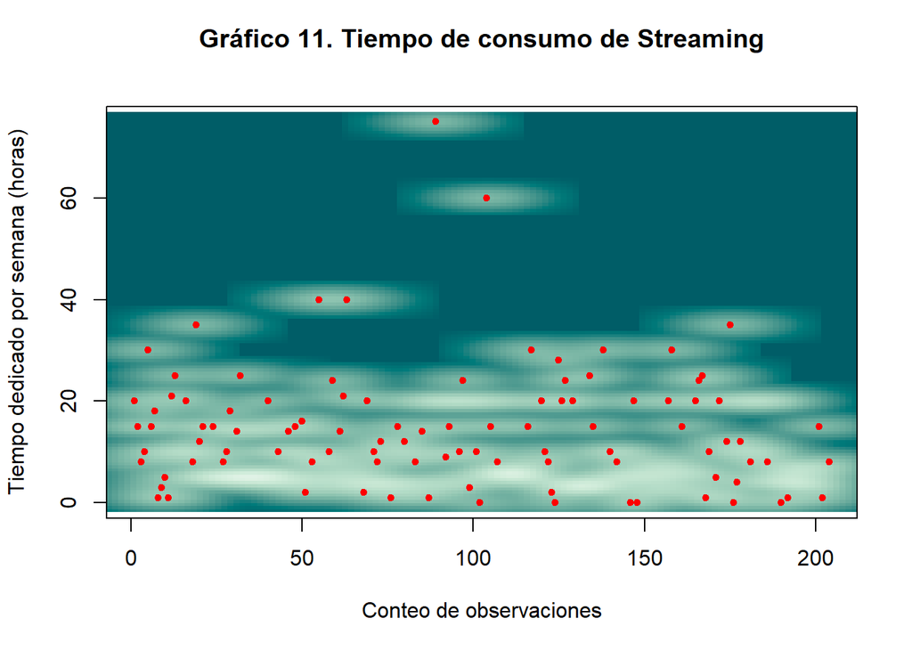

```r
palette <- hcl.colors(30, palette = "mint")
smoothScatter(ISS$Tiempo, xlab='Conteo de observaciones',ylab='Tiempo dedicado por semana (horas)', main="Gráfico 11. Tiempo de consumo de Streaming\n",pch = 20, col = "red",colramp = colorRampPalette(palette))
```

### *Descriptor numérico:*

```r
cat('Número de observaciones de la variable "Tiempo":', sum(complete.cases(ISS$Tiempo)))
```

```
## Número de observaciones de la variable "Tiempo": 204
```

*- Moda*

```r
cat('Moda de la variable "Tiempo":', mfv(ISS$Tiempo),"\n")
```

```
## Moda de la variable "Tiempo": 5 10 20
```

```r
cat('Mediana de la variable "Tiempo":', round(median(ISS$Tiempo, na.rm=TRUE)))
```

```
## Mediana de la variable "Tiempo": 8
```

*- Rango*

```r
range(ISS$Tiempo, na.rm = TRUE)
```

```
## [1]  0 75
```

De acuerdo con el gráfico y con los descriptores, se observa que un total de 204 observaciones (no se encuentra ningún dato vacío) y que las personas encuestadas suelen dedicar entre 5 y 20 horas a la semana a utilizar las servicios de Streaming; donde el rango propuesto fue entre 0 y 112 horas, sin embargo, mientras que se cumplió con el mínimo tiempo dedicado, 0 horas, el máximo tiempo fue de 75 horas.

### *3.12. Cantidad_Plataformas*

En la variable *Cantidad de Plataformas* se recolectaron datos sobre el número de plataformas que tiene cada usuario. A partir de lo indicado se obtuvieron los siguientes datos:

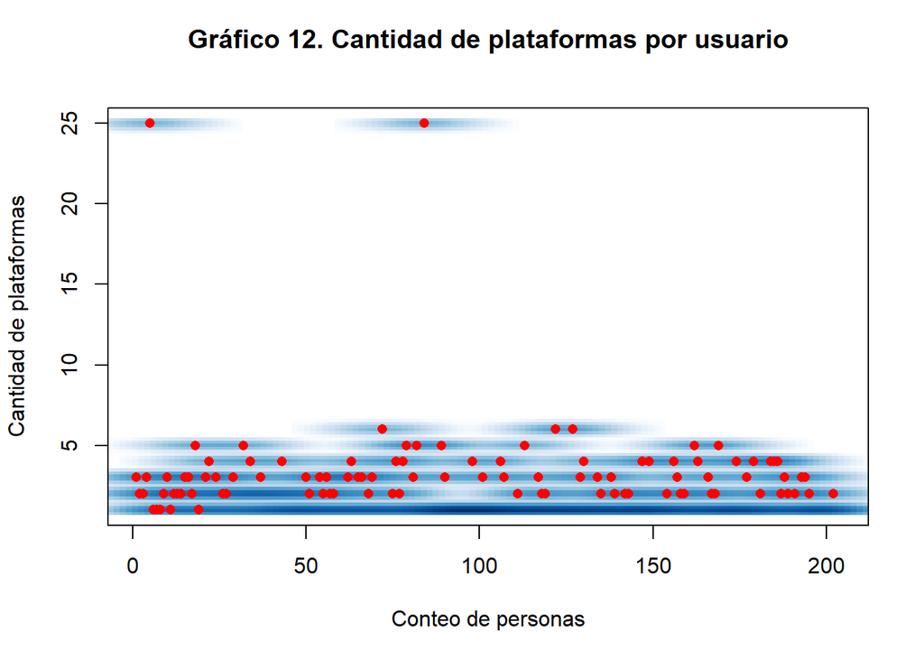

```r
smoothScatter(ISS$Cantidad_Plataformas, ylab='Cantidad de plataformas', xlab ='Conteo de personas', main="Gráfico 12. Cantidad de plataformas por usuario\n",pch = 16, col = "red")
```

### *Descriptor numérico:*

```r
cat('Número de observaciones de la variable "Cantidad de plataformas":', sum(complete.cases(ISS$Cantidad_Plataformas)))
```

```
## Número de observaciones de la variable "Cantidad de plataformas": 204
```

*Mediana*

```r
cat('Mediana de la variable "Cantidad de Plataformas":', median(ISS$Cantidad_Plataformas, na.rm=TRUE))
```

```
## Mediana de la variable "Cantidad de Plataformas": 2
```

*Moda*

```r
cat('Moda de la variable "Cantidad de plataformas":', mfv(ISS$Cantidad_Plataformas))
```

```
## Moda de la variable "Cantidad de plataformas": 1
```

```r
C1 <- filter(ISS, Cantidad_Plataformas == 1)
cat("\n")
```

```r
cat("Número de personas que poseen 1 cuenta de Streaming:", nrow(C1),"\n")
```

```
## Número de personas que poseen 1 cuenta de Streaming: 101
```

*Rango*

```r
range(ISS$Cantidad_Plataformas, na.rm = TRUE)
```

```
## [1]  1 25
```

### *3.13. Satisfacción*

En la variable *Satisfacción* se recolectaron datos sobre el grado de satisfacción que tiene el usuario por las plataformas de streaming que utiliza.A partir de lo indicado se obtuvieron los siguientes datos:

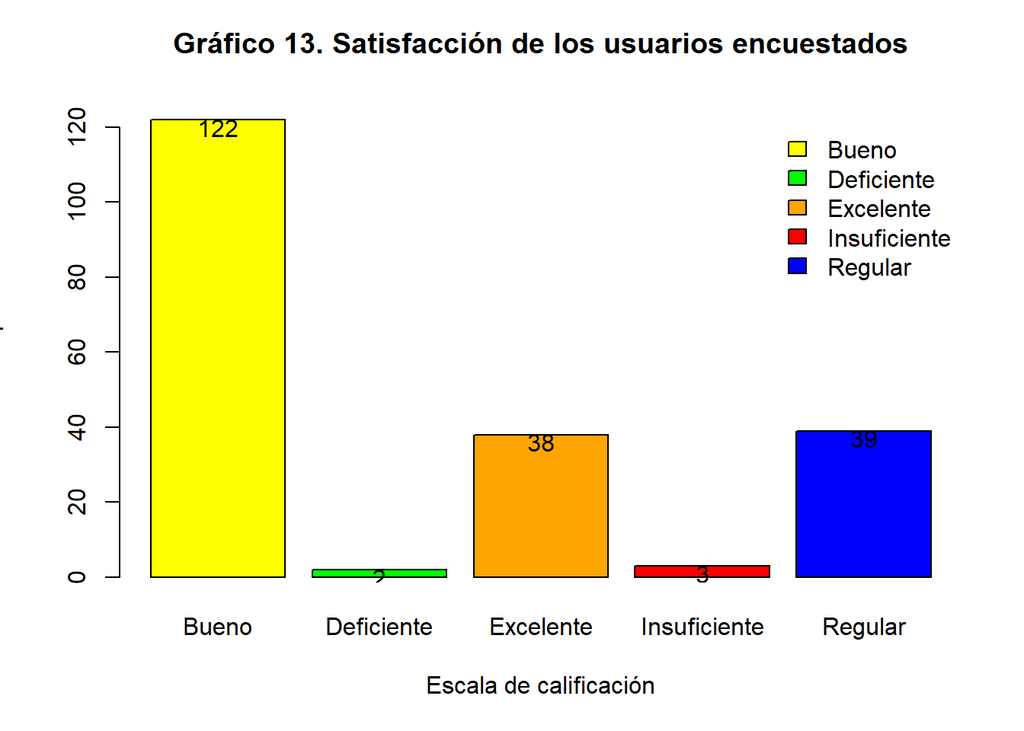

```r
S_S<-table(ISS$Satisfacción)
barp<-barplot(S_S,main = "Gráfico 13. Satisfacción de los usuarios encuestados\n", ylab='Cantidad de personas\n', xlab='\nEscala de calificación',col = c("yellow","green","orange","red","blue"))
text(barp, S_S-2, labels = S_S)

legend('topright', legend=rownames(S_S), bty='n',fill=c("yellow","green","orange","red","blue"))
```

### *Descriptor numérico:*

```r
table(ISS$Satisfacción)
```

```
##
##        Bueno   Deficiente    Excelente Insuficiente      Regular
##          122            2           38            3           39
```

```r
cat('Número de observaciones de la variable "Satisfacción":', sum(complete.cases(ISS$Satisfacción)),"\n")
```

```
## Número de observaciones de la variable "Satisfacción": 204
```

```r
cat("\n")
```

```r
cat('Moda de la variable "Satisfacción":', mfv(ISS$Satisfacción) ,'\n')
```

```
## Moda de la variable "Satisfacción": Bueno
```

```r
BUENO <- filter(ISS, Satisfacción == "Bueno")
cat('Número de personas que califican como "Bueno" los servicios de Streaming:', nrow(BUENO),"\n")
```

```
## Número de personas que califican como "Bueno" los servicios de Streaming: 122
```

De acuerdo con el gráfico y con los descriptores, se observa que un total de 204 observaciones (no se encuentra ningún dato vacío) y que, de las 5 escalas de satisfacción existentes, las personas calificaron mayormente como *Bueno* el servicio que ofrecen las plataformas de Streaming; con un total de 122 observaciones. Por otro lado, se presenta un menor cantidad de personas que califican como *Deficiente* o *Insuficiente* dichos servicios.

### *3.14. Suscribirse*

En la variable *Suscribirse* se recolectaron datos sobre si el usuario estaría interesado por adquirir nuevas plataformas de streaming. A partir de lo indicado se obtuvieron los siguientes datos:

```r
C_SU <-table(ISS$Suscribirse)
C_SU
```

```
##
##  No  Sí
## 122  82
```

```r
S_SI <- filter(ISS, Suscribirse == "Sí")
S_NO <- filter(ISS, Suscribirse == "No")
C_S <- c(nrow(S_SI),nrow(S_NO))
```

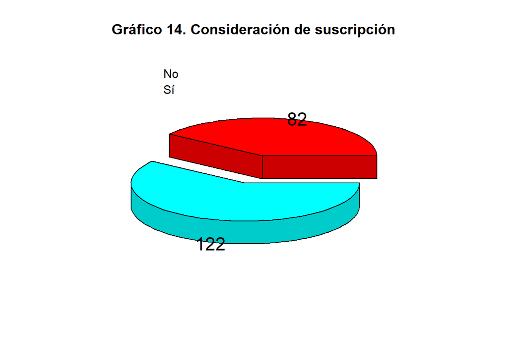

```r
pie3D(C_S,labels = C_S, explode = 0.25, main="Gráfico 14. Consideración de suscripción")
legend('topleft', legend=rownames(C_SU), bty='n',fill=c("skyblue", "red"))
```

### *Descriptor numérico:*

```r
cat('Número de observaciones de la variable "Suscripción":', sum(complete.cases(ISS$Suscribirse)),"\n")
```

```
## Número de observaciones de la variable "Suscripción": 204
```

```r
cat("\n")
```

```r
cat('Moda de la variable "Suscripción":', mfv(ISS$Suscribirse) ,'\n')
```

```
## Moda de la variable "Suscripción": No
```

```r
SUSC <- filter(ISS, Suscribirse == "No")
cat("Número de personas que no consideran suscribirse a más plataformas: ", nrow(SUSC),"\n")
```

```
## Número de personas que no consideran suscribirse a más plataformas:  122
```

De acuerdo con el gráfico y con los descriptores, se observa que un total de 204 observaciones (no se encuentra ningún dato vacío) y que, si bien la persona posee o no servicios de Streaming, 122 personas **no** consideran suscribirse más servicios de Streaming.

### *3.15. Acción*

En la variable *Acción* se recolectaron datos sobre el grado de gustos por género. A partir de lo indicado se obtuvieron los siguientes datos:

```r
C_ACCION <-table(ISS$Accion)
C_ACCION
```

```
##
## A veces / Rara vez     Frecuentemente        No me gusta
##                 58                127                 19
```

```r
AV_ACC <- filter(ISS, Accion == "A veces / Rara vez")
FRE_ACC <- filter(ISS, Accion == "Frecuentemente")
NMG_ACC <- filter(ISS, Accion == "No me gusta")
G_A <- c(nrow(AV_ACC), nrow(FRE_ACC), nrow(NMG_ACC))
```

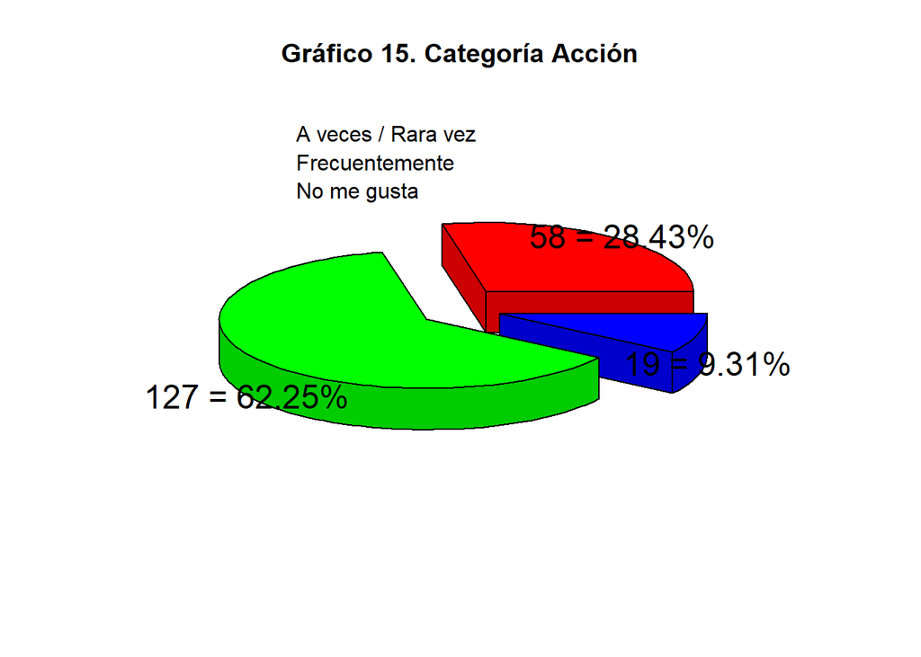

```r
E1 <- paste0(G_A, " = ", round(100 * G_A/sum(G_A), 2), "%")
pie3D(G_A, labels = E1, explode = 0.20, main="Gráfico 15. Categoría Acción")
legend('topleft', legend=rownames(C_ACCION), bty='n',fill=c("red", "green","blue"))
```

### *3.16. Drama*

En la variable *Drama* se recolectaron datos sobre el grado de gustos por género. A partir de lo indicado se obtuvieron los siguientes datos:

```r
C_DRAMA <-table(ISS$Drama)
C_DRAMA
```

```
##
## A veces / Rara vez     Frecuentemente        No me gusta
##                 97                 80                 27
```

```r
AV_DRA <- filter(ISS, Drama == "A veces / Rara vez")
FRE_DRA <- filter(ISS, Drama == "Frecuentemente")
NMG_DRA <- filter(ISS, Drama == "No me gusta")
G_DR <- c(nrow(AV_DRA), nrow(FRE_DRA), nrow(NMG_DRA))
```

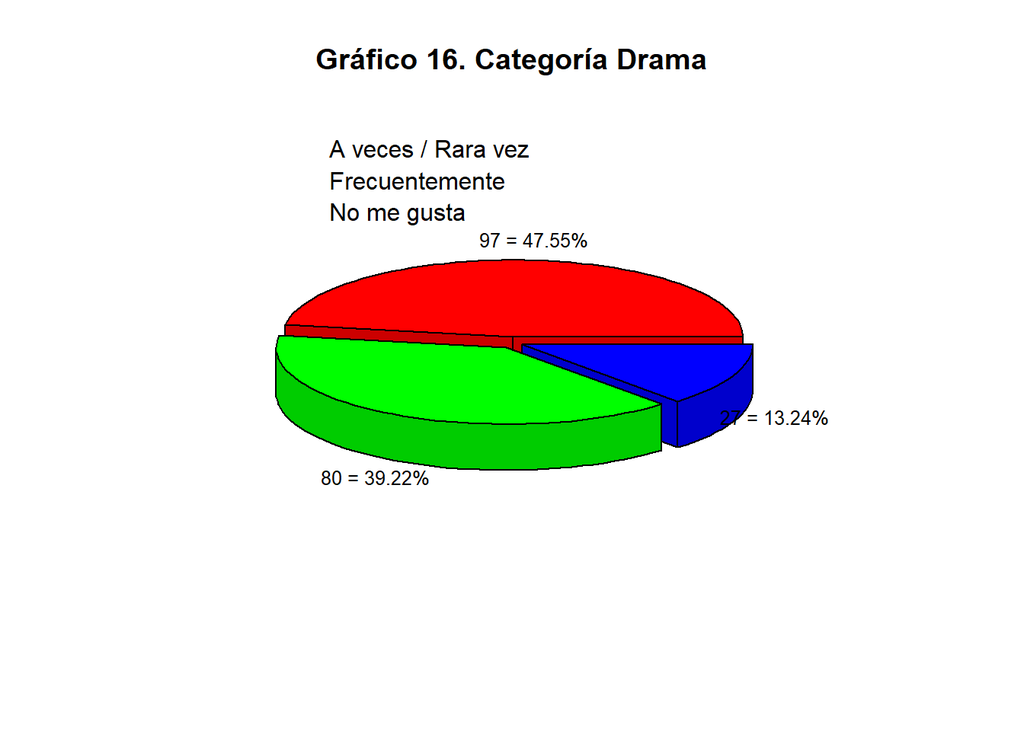

```r
E2 <- paste0(G_DR, " = ", round(100 * G_DR/sum(G_DR), 2), "%")
pie3D(G_DR, labels = E2, labelcex = 0.8, explode = 0.05, main="Gráfico 16. Categoría Drama")
legend('topleft', legend=rownames(C_ACCION), bty='n',fill=c("red", "green","blue"))
```

### *3.17. Comedia*

En la variable *Comedia* se recolectaron datos sobre el grado de gustos por género. A partir de lo indicado se obtuvieron los siguientes datos:

```r
C_COMEDIA <-table(ISS$Comedia)
C_COMEDIA
```

```
##
## A veces / Rara vez     Frecuentemente        No me gusta
##                 73                113                 18
```

```r
AV_COM <- filter(ISS, Comedia == "A veces / Rara vez")
FRE_COM <- filter(ISS, Comedia == "Frecuentemente")
NMG_COM <- filter(ISS, Comedia == "No me gusta")
G_COM <- c(nrow(AV_COM), nrow(FRE_COM), nrow(NMG_COM))
```

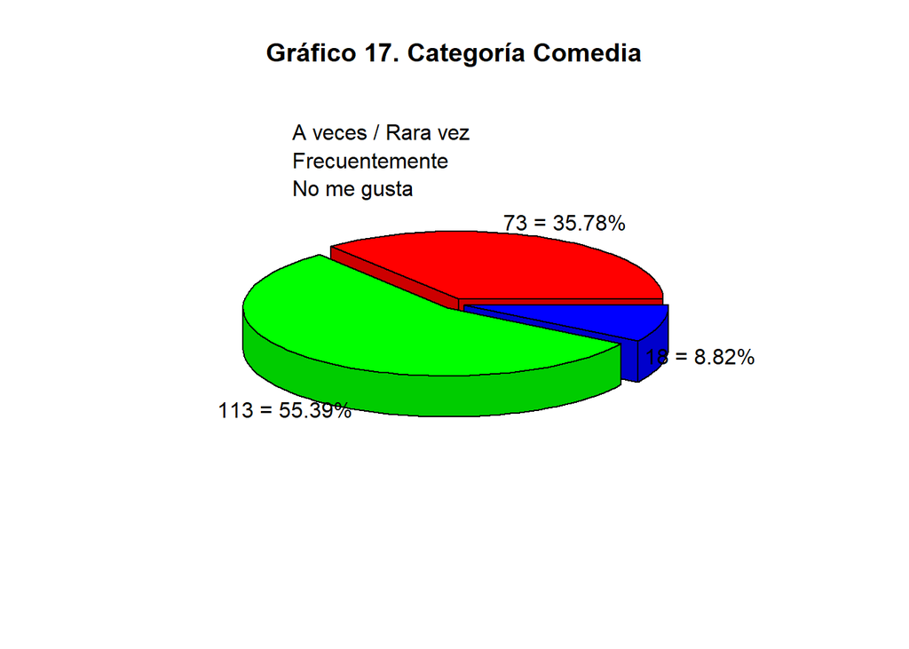

```r
E3 <- paste0(G_COM, " = ", round(100 * G_COM/sum(G_COM), 2), "%")
pie3D(G_COM, labels = E3, labelcex = 1, explode = 0.05, main="Gráfico 17. Categoría Comedia")
legend('topleft', legend=rownames(C_COMEDIA), bty='n',fill=c("red", "green","blue"))
```

### *3.18. Terror*

En la variable *Terror* se recolectaron datos sobre el grado de gustos por género. A partir de lo indicado se obtuvieron los siguientes datos:

```r
C_TERROR <-table(ISS$Terror)
C_TERROR
```

```
##
## A veces / Rara vez     Frecuentemente        No me gusta
##                 71                 68                 65
```

```r
AV_TER <- filter(ISS, Terror == "A veces / Rara vez")
FRE_TER <- filter(ISS, Terror == "Frecuentemente")
NMG_TER <- filter(ISS, Terror == "No me gusta")
G_TER <- c(nrow(AV_TER), nrow(FRE_TER), nrow(NMG_TER))
```

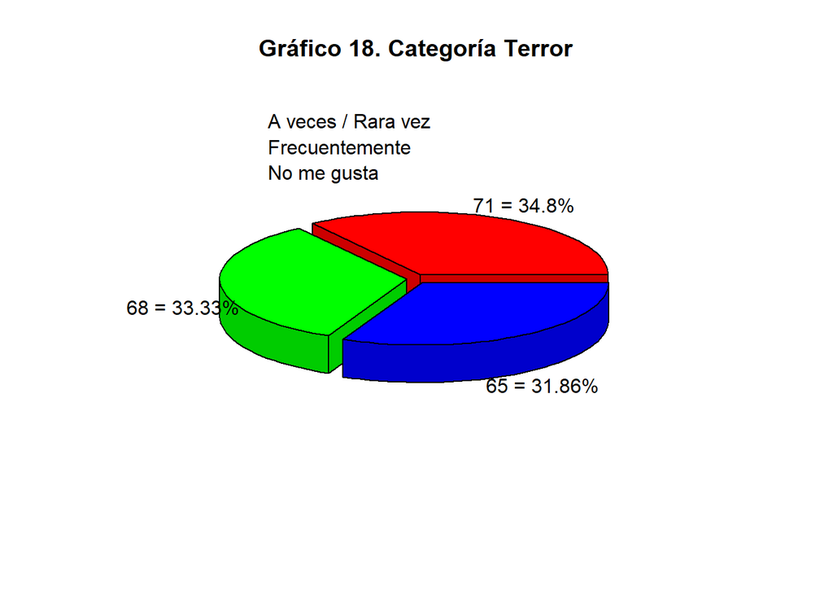

```r
E4 <- paste0(G_TER, " = ", round(100 * G_TER/sum(G_TER), 2), "%")
pie3D(G_TER, labels = E4, labelcex = 1, explode = 0.05, main="Gráfico 18. Categoría Terror")
legend('topleft', legend=rownames(C_TERROR), bty='n',fill=c("red", "green","blue"))
```